# Financial Time Series Models (ARCH/GARCH)

Published

November 17, 2025

In the earlier sections, we examined trade patterns, external drivers, and supply-chain shocks affecting activity at the Port of Los Angeles. To extend this analysis from a financial perspective, we use the returns of the Dow Jones Transportation (DJT) to study volatility in the transportation sector.

Because DJT is closely linked to port activity and logistics conditions, its returns exhibit clear volatility clustering—periods of high turbulence tend to follow one another, as do calmer periods. To capture this behavior, we apply ARCH/GARCH models to examine how transportation-sector volatility responds to major events such as financial crises and the COVID-19 pandemic, offering additional insight into supply-chain-related risk.

# Time Series Plot

The Dow Jones Transportation is a market index that tracks major U.S. transportation and logistics companies, including airlines, railroads, trucking firms, and shipping carriers. Because it reflects investors’ expectations about freight demand, supply-chain conditions, and trade activity, the DJT behaves much like any financial asset whose price varies over time. Therefore, we treat the DJT as an asset price series and compute its returns to capture both its continuous growth rate and its time-varying volatility. This allows us to model how the transportation sector responds to economic shocks and supply-chain disruptions.

**Original DJT**

```r
library(tidyverse)
library(ggplot2)
library(forecast)
library(astsa)
library(xts)
library(tseries)
library(fpp2)
library(fma)
library(lubridate)
library(tidyverse)
library(TSstudio)
library(quantmod)
library(tidyquant)
library(plotly)
library(ggplot2)
library(knitr)
library(kableExtra)
library(fGarch)
library(dplyr)
library(dplyr)

# Get DJT data
invisible(getSymbols("^DJT", src = "yahoo",
                     from = "2000-01-01", to = "2025-08-30"))

# Build clean dataframe
djt <- data.frame(
  Date = index(DJT),
  Open = as.numeric(DJT[, "DJT.Open"]),
  High = as.numeric(DJT[, "DJT.High"]),
  Low  = as.numeric(DJT[, "DJT.Low"]),
  Close = as.numeric(DJT[, "DJT.Close"]),
  Adjusted = as.numeric(DJT[, "DJT.Adjusted"])
)

djt<- na.omit(djt)
djt$Date <- as.Date(djt$Date)

# Candlestick plot (fixed)
fig_djt <- plot_ly(
  data = djt,
  x = ~Date,
  type = "candlestick",
  open = ~Open,
  close = ~Close,
  high = ~High,
  low = ~Low
)

fig_djt <- fig_djt %>%
  layout(title = "Dow Jones Transportation Average (DJT) — Candlestick Plot")

fig_djt
```

[interactive chart not shown]

**Log Price**

```r
library(ggplot2)
library(plotly)
library(scales)

gg <- ggplot(djt, aes(x = Date, y = log(Adjusted))) +
  geom_line(color = '#7faf7f') +
  scale_x_date(date_breaks = "5 years",
               date_labels = "%Y") +
  labs(x = "Year", title = "Log-transformed DJT")

ggplotly(gg)
```

[interactive chart not shown]

**Daily Log Returns**

We transform prices into log returns for two main reasons:

- Stationarity Prices are typically non-stationary, while returns are closer to stationary, making them suitable for ARIMA and ARCH/GARCH modeling.
- Volatility analysis Log returns highlight volatility clustering, where periods of high turbulence tend to occur together, followed by calmer intervals.

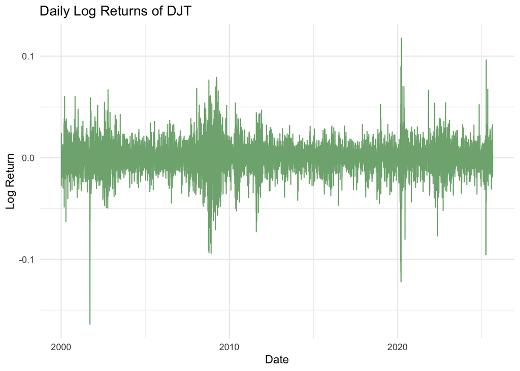

```r
ret <- diff(log(djt$Adjusted))
ret <- na.omit(ret)
# Plot log returns using autoplot
returns <- data.frame(
  Date = djt$Date[-1],
  Return = ret
)

ggplot(returns, aes(x = Date, y = ret)) +
  geom_line(color = "#7faf7f") +
  labs(title = "Daily Log Returns of DJT",
       x = "Date",
       y = "Log Return") +
  theme_minimal()
```

From the plot, we observe sharp spikes during events such as the 2008 financial crisis and the 2020 COVID-19 pandemic, confirming the need for ARCH/GARCH models to capture the time-varying volatility.

# ACF and PACF Plots

**Absolute Returns**

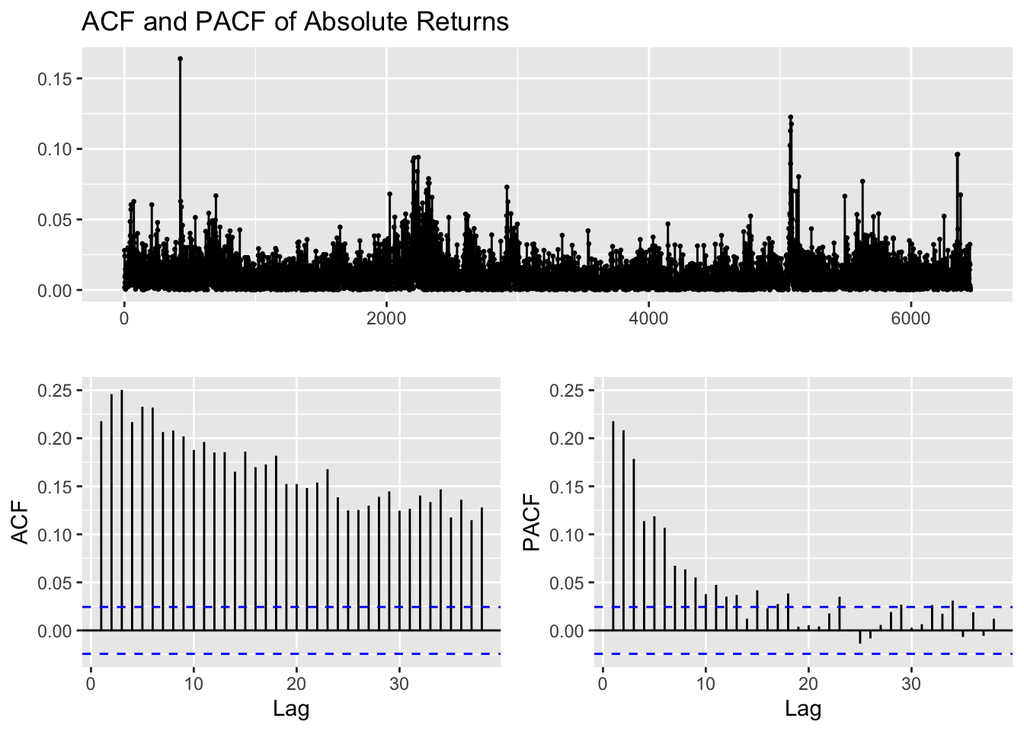

```r
ggtsdisplay(abs(ret), main="ACF and PACF of Absolute Returns")
```

The absolute returns exhibit strong and persistent autocorrelation, showing clear volatility clustering.

**Squared Returns**

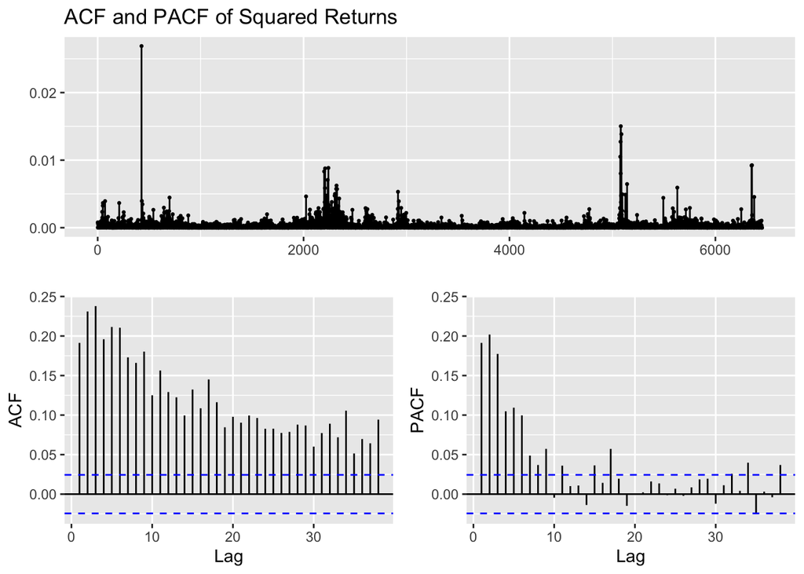

```r
ggtsdisplay(ret^2, main="ACF and PACF of Squared Returns")
```

The squared returns display significant autocorrelation across many lags, confirming the presence of ARCH/GARCH effects.

# ARIMA + GARCH Model

There are two common approaches to fitting a GARCH model to time series data. The first approach involves fitting an ARIMA model to the actual prices to capture the conditional mean dynamics. The residuals from the ARIMA model are then used to fit a GARCH model to model the time-varying volatility. The second approach is to apply the GARCH model directly to the returns series.

**Model Selection**

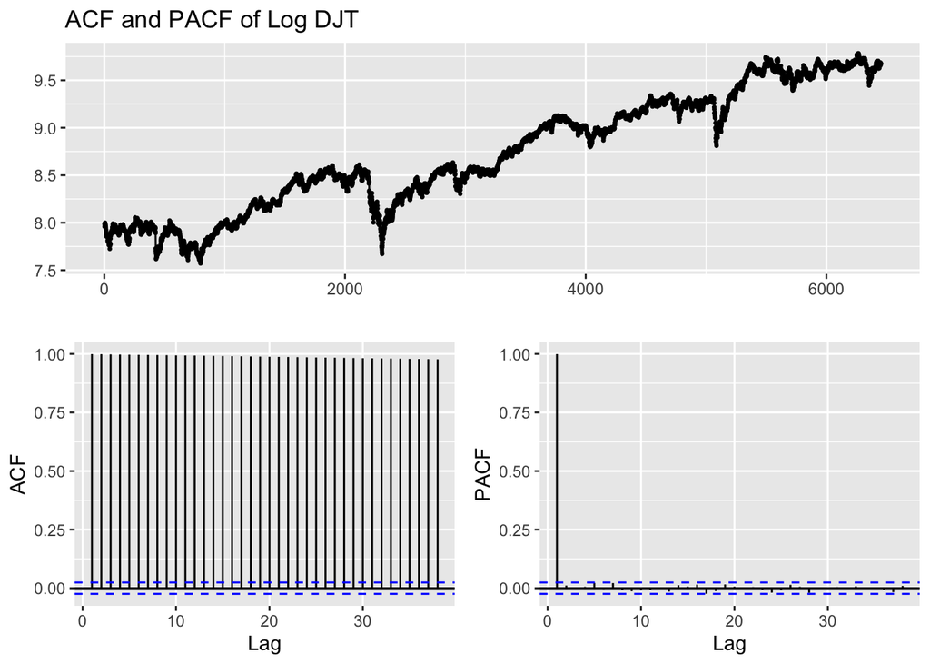

```r
ggtsdisplay(log(djt$Adjusted), main="ACF and PACF of Log DJT")
```

The ACF plot of the log-transformed DJT shows significant autocorrelations at multiple lags. This gradual decay suggests that the log prices exhibit long-term dependencies, indicating differnecing is needed to make the series stationary.

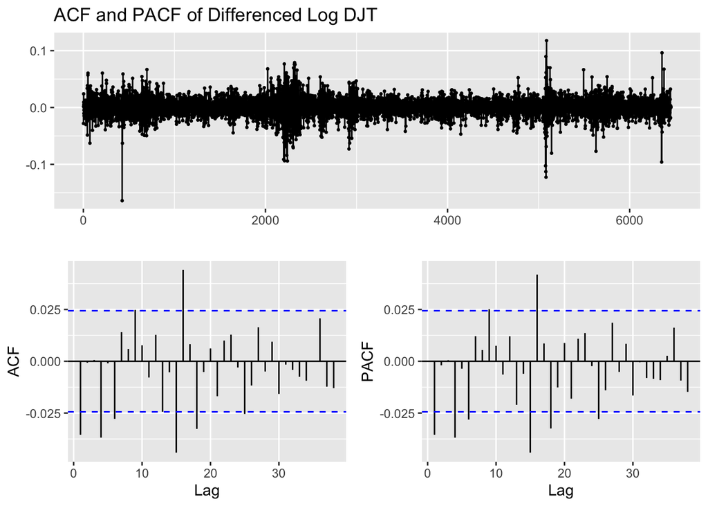

```r
ggtsdisplay(diff(log(djt$Adjusted)), main="ACF and PACF of Differenced Log DJT")
```

I’ll choose q & p for (0,4).

**Manual Search**

```r
ARIMA.c = function(p1, p2, q1, q2, data) {
  d = 1
  i = 1
  temp = data.frame()
  ls = matrix(rep(NA, 6 * 1000), nrow = 1000)

  for (p in p1:p2) {
    for (q in q1:q2) {
          if (p + d + q <= 9) {

            model <- tryCatch({
              Arima(data, order = c(p, d, q), include.drift = TRUE)
            }, error = function(e) {
              return(NULL)
            })

            if (!is.null(model)) {
              ls[i, ] = c(p, d, q, model$aic, model$bic, model$aicc)
              i = i + 1
            }
          }
        }
      }
      temp = as.data.frame(ls)
      names(temp) = c("p", "d", "q", "AIC", "BIC", "AICc")
      temp = na.omit(temp)
      return(temp)
}

highlight_output = function(output, type="ARIMA") {
    highlight_row <- c(which.min(output$AIC), which.min(output$BIC), which.min(output$AICc))
    knitr::kable(output, align = 'c', caption = paste("Comparison of", type, "Models")) %>%
    kable_styling(full_width = FALSE, position = "center") %>%
    row_spec(highlight_row, bold = TRUE, background = "#FFFF99")  # Highlight row in yellow
}

output=ARIMA.c(p1=0,p2=4,q1=0,q2=4,data=log(djt$Adjusted))
highlight_output(output)
```

Comparison of ARIMA Models

| p | d | q | AIC | BIC | AICc |
| --- | --- | --- | --- | --- | --- |
| 0 | 1 | 0 | -35346.41 | -35332.87 | -35346.41 |
| 0 | 1 | 1 | -35352.55 | -35332.23 | -35352.54 |
| 0 | 1 | 2 | -35350.55 | -35323.46 | -35350.54 |
| 0 | 1 | 3 | -35348.58 | -35314.72 | -35348.57 |
| 0 | 1 | 4 | -35355.33 | -35314.69 | -35355.31 |
| 1 | 1 | 0 | -35352.52 | -35332.21 | -35352.52 |
| 1 | 1 | 1 | -35350.54 | -35323.45 | -35350.53 |
| 1 | 1 | 2 | -35348.55 | -35314.69 | -35348.54 |
| 1 | 1 | 3 | -35346.56 | -35305.93 | -35346.55 |
| 1 | 1 | 4 | -35353.32 | -35305.91 | -35353.30 |
| 2 | 1 | 0 | -35350.55 | -35323.46 | -35350.54 |
| 2 | 1 | 1 | -35348.55 | -35314.69 | -35348.54 |
| 2 | 1 | 2 | -35346.39 | -35305.75 | -35346.37 |
| 2 | 1 | 3 | -35345.00 | -35297.59 | -35344.98 |
| 2 | 1 | 4 | -35353.93 | -35299.75 | -35353.91 |
| 3 | 1 | 0 | -35348.55 | -35314.69 | -35348.54 |
| 3 | 1 | 1 | -35346.55 | -35305.92 | -35346.54 |
| 3 | 1 | 2 | -35344.55 | -35297.14 | -35344.53 |
| 3 | 1 | 3 | -35347.41 | -35293.23 | -35347.39 |
| 3 | 1 | 4 | -35357.19 | -35296.24 | -35357.16 |
| 4 | 1 | 0 | -35355.31 | -35314.68 | -35355.30 |
| 4 | 1 | 1 | -35353.35 | -35305.94 | -35353.33 |
| 4 | 1 | 2 | -35354.40 | -35300.22 | -35354.38 |
| 4 | 1 | 3 | -35357.63 | -35296.68 | -35357.60 |
| 4 | 1 | 4 | -35358.82 | -35291.09 | -35358.78 |

The manual search choose arima(0,1,0), arima(4,1,4) as the best model.

**Auto Search**

```r
auto.arima(log(djt$Adjusted))
```

```
Series: log(djt$Adjusted)
ARIMA(1,1,0)

Coefficients:
          ar1
      -0.0352
s.e.   0.0124

sigma^2 = 0.0002444:  log likelihood = 17678.29
AIC=-35352.59   AICc=-35352.59   BIC=-35339.04
```

The auto search choose arima(1,1,0) as the best model

**Model Diagnostics**

**ARIMA(0,1,0)**

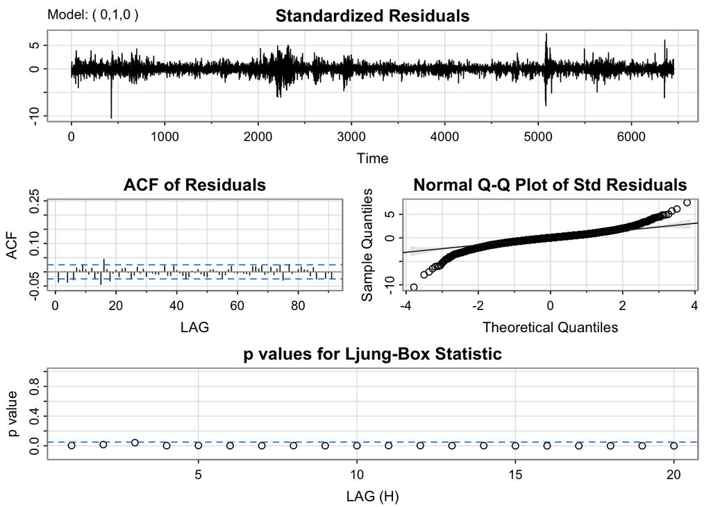

```r
model_output_1 <- capture.output(sarima(log(djt$Adjusted), 0,1,0))
```

```r
start_line <- grep("Coefficients", model_output_1)  # Locate where coefficient details start
end_line <- length(model_output_1)  # Last line of output
cat(model_output_1[start_line:end_line], sep = "\n")
```

```
Coefficients:
         Estimate    SE t.value p.value
constant    3e-04 2e-04  1.3401  0.1803

sigma^2 estimated as 0.0002445689 on 6452 degrees of freedom

AIC = -5.477516  AICc = -5.477516  BIC = -5.475417
```

**ARIMA(4,1,4)**

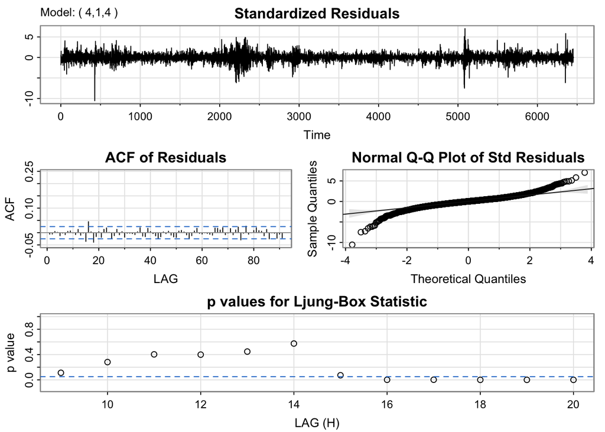

```r
model_output_2 <- capture.output(sarima(log(djt$Adjusted), 4,1,4))
```

```r
start_line <- grep("Coefficients", model_output_2)  # Locate where coefficient details start
end_line <- length(model_output_2)  # Last line of output
cat(model_output_2[start_line:end_line], sep = "\n")
```

```
Coefficients:
         Estimate     SE t.value p.value
ar1        0.0502 0.3879  0.1295  0.8969
ar2        0.6648 0.3278  2.0282  0.0426
ar3       -0.3280 0.1807 -1.8156  0.0695
ar4       -0.5720 0.4171 -1.3715  0.1703
ma1       -0.0798 0.4032 -0.1979  0.8431
ma2       -0.6601 0.3377 -1.9547  0.0507
ma3        0.3433 0.1905  1.8019  0.0716
ma4        0.5230 0.4345  1.2036  0.2288
constant   0.0003 0.0002  1.4187  0.1560

sigma^2 estimated as 0.0002434939 on 6444 degrees of freedom

AIC = -5.479438  AICc = -5.479434  BIC = -5.468943
```

**ARIMA(1,1,0)**

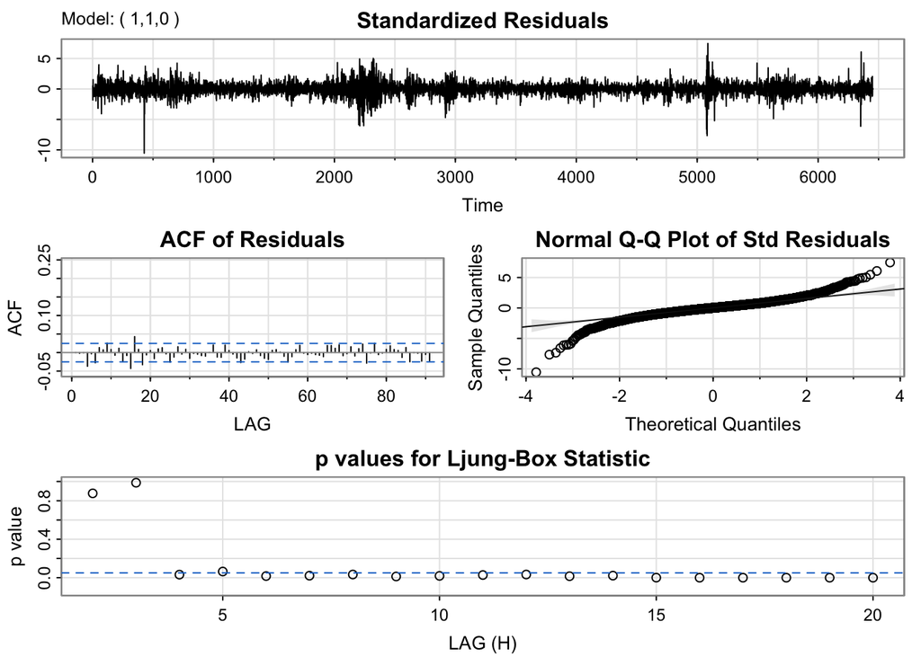

```r
model_output_3 <- capture.output(sarima(log(djt$Adjusted), 1,1,0))
```

```r
start_line <- grep("Coefficients", model_output_3)  # Locate where coefficient details start
end_line <- length(model_output_3)  # Last line of output
cat(model_output_3[start_line:end_line], sep = "\n")
```

```
Coefficients:
         Estimate     SE t.value p.value
ar1       -0.0354 0.0124 -2.8488  0.0044
constant   0.0003 0.0002  1.3894  0.1648

sigma^2 estimated as 0.0002442617 on 6451 degrees of freedom

AIC = -5.478463  AICc = -5.478463  BIC = -5.475315
```

**Model Fitting**

**ARIMA(1,1,0)**

```r
# Fit ARIMA(1,1,0) model to the log-transformed stock prices
arima_110 <- Arima(log(djt$Adjusted), order = c(1,1,0))
summary(arima_110)
```

```
Series: log(djt$Adjusted)
ARIMA(1,1,0)

Coefficients:
          ar1
      -0.0352
s.e.   0.0124

sigma^2 = 0.0002444:  log likelihood = 17678.29
AIC=-35352.59   AICc=-35352.59   BIC=-35339.04

Training set error measures:
                       ME       RMSE        MAE        MPE      MAPE     MASE
Training set 0.0002718117 0.01563032 0.01107797 0.00291448 0.1285823 1.000066
                      ACF1
Training set -0.0004887902
```

## GARCH on Residuals

Fit a GARCH model to the residuals of the ARIMA model.

**Model Selection**

To determine the appropriate values for GARCH(p, q), we examine the ACF and PACF plots of the squared residuals from the ARIMA model. Significant spikes in the ACF and PACF at certain lags can provide insight into the orders of p (ARCH terms) and q (GARCH terms) for the GARCH model. Specifically, the number of significant lags in the ACF and PACF can guide the selection of the GARCH model’s parameters.

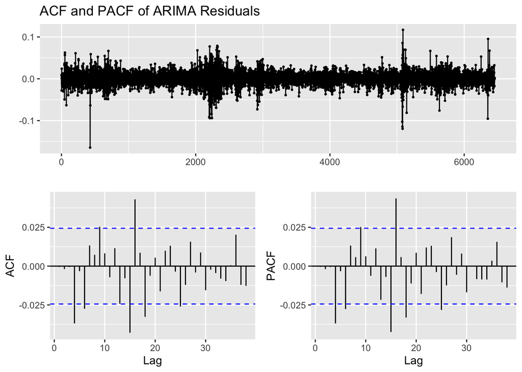

```r
# Get residuals from the fitted ARIMA model
arima.res <- arima_110$residuals
# Compute squared residuals
squared.arima.res <- arima.res^2
ggtsdisplay(arima.res, main="ACF and PACF of ARIMA Residuals")
```

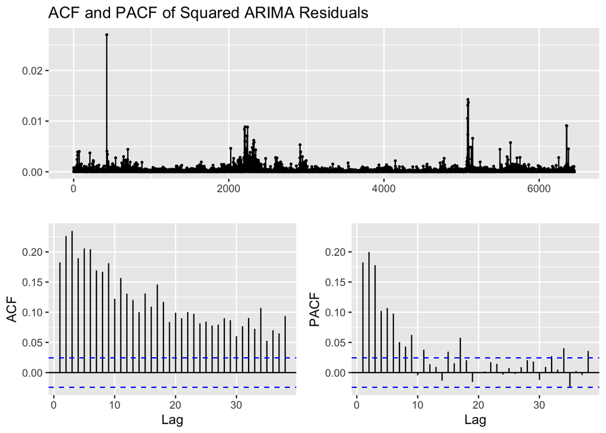

```r
ggtsdisplay(squared.arima.res, main="ACF and PACF of Squared ARIMA Residuals")
```

Significant spikes at lags 1–4 in the ACF of squared residuals suggest the presence of potential ARCH effects, indicating time-varying volatility in the data. Additionally, the PACF of squared residuals reveals structure at lags 1-3, further supporting the need for fitting an ARCH model to capture these dependencies.

**Manual Search**

```r
# Initialize list to store models
models <- list()
cc <- 1

# Loop over GARCH(p, q) combinations
for (p in 1:3) {
  for (q in 1:4) {
    models[[cc]] <- garch(arima.res, order = c(q, p), trace = FALSE)
    cc <- cc + 1
  }
}

# Extract AIC values for all models
GARCH_AIC <- sapply(models, AIC)

# Find and return the best model (lowest AIC)
best_index <- which.min(GARCH_AIC)
models[[best_index]]
```

```
Call:
garch(x = arima.res, order = c(q, p), trace = FALSE)

Coefficient(s):
       a0         a1         b1
4.936e-06  8.721e-02  8.923e-01
```

This suggests that the best model is GARCH(1,1), as it yields the lowest AIC, indicating a better fit to the data compared to other models.

**Model Fitting**

```r
# Fit a GARCH(1,1) model to ARIMA residuals and display summary
garch_model <- garchFit(~ garch(1,1), data = arima.res, trace = FALSE)
summary(garch_model)
```

```
Title:
 GARCH Modelling

Call:
 garchFit(formula = ~garch(1, 1), data = arima.res, trace = FALSE)

Mean and Variance Equation:
 data ~ garch(1, 1)
<environment: 0x1239325c0>
 [data = arima.res]

Conditional Distribution:
 norm

Coefficient(s):
        mu       omega      alpha1       beta1
5.6391e-04  4.9532e-06  8.7346e-02  8.9203e-01

Std. Errors:
 based on Hessian

Error Analysis:
        Estimate  Std. Error  t value Pr(>|t|)
mu     5.639e-04   1.537e-04    3.670 0.000243 ***
omega  4.953e-06   7.567e-07    6.546 5.91e-11 ***
alpha1 8.735e-02   7.669e-03   11.390  < 2e-16 ***
beta1  8.920e-01   9.330e-03   95.613  < 2e-16 ***
---
Signif. codes:  0 '***' 0.001 '**' 0.01 '*' 0.05 '.' 0.1 ' ' 1

Log Likelihood:
 18521.22    normalized:  2.869728

Description:
 Tue Nov 18 04:23:39 2025 by user:


Standardised Residuals Tests:
                                  Statistic    p-Value
 Jarque-Bera Test   R    Chi^2  4194.606286 0.00000000
 Shapiro-Wilk Test  R    W               NA         NA
 Ljung-Box Test     R    Q(10)    17.361203 0.06674389
 Ljung-Box Test     R    Q(15)    24.623454 0.05523460
 Ljung-Box Test     R    Q(20)    28.496765 0.09815155
 Ljung-Box Test     R^2  Q(10)     6.158276 0.80179487
 Ljung-Box Test     R^2  Q(15)     7.339588 0.94753236
 Ljung-Box Test     R^2  Q(20)     8.968039 0.98327450
 LM Arch Test       R    TR^2      6.298362 0.90030102

Information Criterion Statistics:
      AIC       BIC       SIC      HQIC
-5.738217 -5.734019 -5.738217 -5.736764
```

**Forecasting**

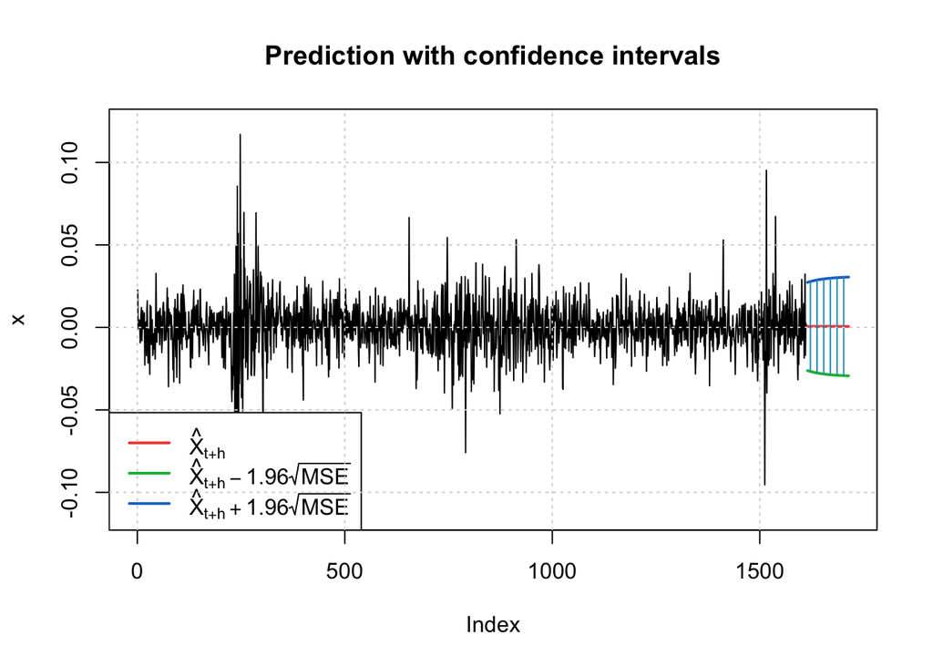

```r
# Predict 100 steps ahead using the fitted GARCH(1,1) model
invisible(predict(garch_model, n.ahead = 100, plot = TRUE))
```

## ARIMA(1,1,0)+GARCG(1,1) Model Equation

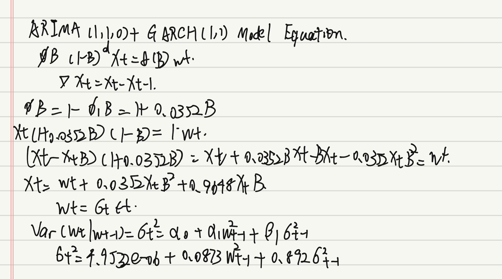

arima+garch

# GARCH Model

The second approach involves directly fitting a GARCH model to the returns, without fitt the ARIMA model. In this method, we inspect the ACF and PACF of the squared returns, rather than using ARIMA residuals, to determine the appropriate GARCH model.

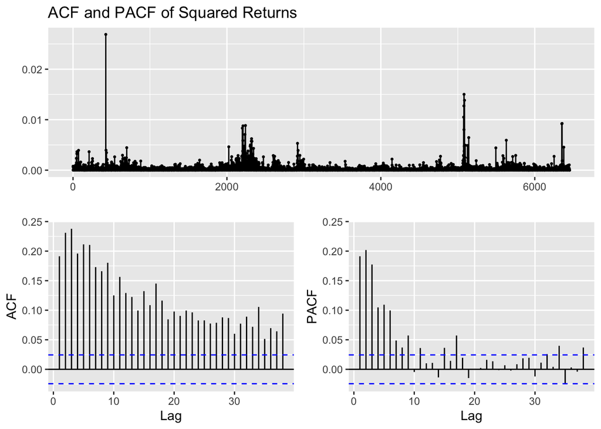

```r
ggtsdisplay(ret^2, main="ACF and PACF of Squared Returns")
```

I’ll choose q(1:4), p(1:4)

```r
# Initialize model storage
models <- list()
cc <- 1

# Grid search for GARCH(p, q), where p = ARCH order, q = GARCH order
for (p in 1:4) {
  for (q in 1:4) {
    models[[cc]] <- garch(ret, order = c(q, p), trace = FALSE)
    cc <- cc + 1
  }
}

# Extract AIC values
garch_aic <- sapply(models, AIC)

# Find best model (lowest AIC)
best_index <- which.min(GARCH_AIC)
models[[best_index]]
```

```
Call:
garch(x = ret, order = c(q, p), trace = FALSE)

Coefficient(s):
       a0         a1         b1
4.920e-06  8.716e-02  8.924e-01
```

# Cross Validation

Next I’ll compare Method 1: ARIMA(1,1,0) + GARCH(1,1) and Method 2: GARCH(1,1).

```r
log.b   <- log(djt$Adjusted)
returns <- diff(log.b)
n  <- length(log.b)

# 80% trian, 20% test
train_end <- floor(0.8 * n)
train <- log.b[1:train_end]
test  <- log.b[(train_end + 1):n]

# Model 1: ARIMA(1,1,0) + GARCH(1,1)
arima.fit <- Arima(train, order = c(1,1,0), include.drift = TRUE)
arima.res <- residuals(arima.fit)
fit1      <- garchFit(~ garch(1, 1), data = arima.res, trace = FALSE)

fc_arima  <- forecast(arima.fit, h = length(test))$mean
fc_garch1 <- predict(fit1, n.ahead = length(test))$meanForecast
pred1     <- fc_arima + fc_garch1

# Model 2: GARCH(1,1) on returns
ret_train <- diff(train)
fit2      <- garchFit(~ garch(1, 1), data = ret_train, trace = FALSE)
ret_fc2   <- predict(fit2, n.ahead = length(test))$meanForecast

pred2 <- numeric(length(test))
pred2[1] <- tail(train, 1) + ret_fc2[1]
for (i in 2:length(test)) {
  pred2[i] <- pred2[i-1] + ret_fc2[i]
}

RMSE1 <- sqrt(mean((pred1 - test)^2))
RMSE2 <- sqrt(mean((pred2 - test)^2))

tabel <- data.frame(
  Model = c("ARIMA(1,1,0)+GARCH(1,1)", "GARCH(1,1)"),
  RMSE = round(c(RMSE1, RMSE2), 4)
)
highlight_row <- which.min(tabel$RMSE)
kable(tabel, align = 'c', caption = "Model Comparison Based on RMSE") %>%
  kable_styling(full_width = FALSE, position = "center") %>%
  row_spec(highlight_row, bold = TRUE, background = "#FFFF99")
```

Model Comparison Based on RMSE

| Model | RMSE |
| --- | --- |
| ARIMA(1,1,0)+GARCH(1,1) | 0.3179 |
| GARCH(1,1) | 0.1948 |

# Volatality Plot

```r
# Extract the conditional variances from GARCH
ht <- garch_model@h.t

# Create dataframe and plot
vol_df <- data.frame(Date = djt$Date, Volatility = ht)

p <- ggplot(vol_df, aes(x = Date, y = Volatility)) +
  geom_line(color = "#9999cc") +
  labs(
    title = "Volatility Plot (Conditional Variance from GARCH Model)",
    x = "Date",
    y = "Conditional Variance"
  ) +
  theme_minimal()

ggplotly(p)
```

[interactive chart not shown]

This chart shows the conditional variance (volatility) of the Dow Jones Transportation Average (DJT), estimated using a GARCH model.

Since DJT reflects the performance of airlines, railroads, trucking, shipping, and delivery companies, its volatility reacts strongly to trade cycles, logistics disruptions, oil price shocks, and macroeconomic uncertainty.

Several distinct spikes correspond to well-known economic and global events:

- **2001–2002: Dot-com Bust & 9/11 Attacks**

The collapse of the tech bubble pushed the U.S. economy into recession, while the 9/11 attacks caused an unprecedented shutdown of air travel and cargo movement. DJT experienced a sharp jump in volatility as transportation activity dropped abruptly.

- **2008–2009: Global Financial Crisis**

The financial crisis caused a severe decline in global freight volumes. Transport companies faced collapsing demand, shipping disruptions, and extreme oil price swings. DJT volatility surged to one of its highest levels in the entire period.

- **2010–2011: European Debt Crisis & Post-Crisis Supply Chain Stress**

The Eurozone debt crisis, slow U.S. recovery, and fragile global trade conditions created uncertainty for freight and logistics companies. This period saw several medium-sized volatility spikes in DJT.

- **2014–2015: Oil Price Collapse & Trade Slowdown**

The dramatic fall in oil prices created mixed signals: Lower costs benefited airlines and trucking companies. But global trade weakened significantly. This tension resulted in elevated volatility in DJT during 2014–2015.

- **2020: COVID-19 Pandemic**

The pandemic produced historic disruptions: Air travel collapsed; Ports became congested; Supply chains broke down; Freight demand first crashed and then surged. This led to the most extreme volatility peak in the entire series.

- **2021–2022: Supply Chain Crisis & Fed Tightening**

Post-pandemic recovery created record-high congestion in major ports and extreme freight volatility. In 2022, aggressive Federal Reserve rate hikes increased recession fears, triggering another rise in DJT volatility.